# Projekt Zaliczeniowy - Techniki Imputacji Danych

Jakub Kur, Jula Bulińska, Łukasz Szweda

01 08 2021

Import do R; nadanie brakujacych nazw kolumn; Zmiana wartosci ze znakiem zapytania na niewystepujace **“?” -> NA**

Informacje o zmiennych można znaleźć na stronie z danymi  
[Communities and Crime Unnormalized Data Set](https://archive.ics.uci.edu/ml/datasets/Communities+and+Crime+Unnormalized)

Po zapoznaniu się ze z tymi informacjami nadano rodzaj dla pierwszych trzydziestu zmiennych zweryfikowano ich typ:

```r
library(knitr) #formating tables
df2 = data.frame(VariableName = coltitles[1:30], VariableDesc = var_desc[1:30],VariableType = var_typzmiennej )
kable(df2)
```

| VariableName | VariableDesc | VariableType |
| --- | --- | --- |
| communityname | Community name - not predictive - for information only (string) | Nominalna |
| state | US state (by 2 letter postal abbreviation)(nominal) | Nominalna |
| countyCode | numeric code for county - not predictive, and many missing values (numeric) | Nominalna |
| communityCode | numeric code for community - not predictive and many missing values (numeric) | Nominalna |
| fold | fold number for non-random 10 fold cross validation, potentially useful for debugging, paired tests - not predictive (numeric - integer) | Nominalna |
| population | population for community: (numeric - expected to be integer) | Ilorazowa |
| householdsize | mean people per household (numeric - decimal) | Ilorazowa |
| racepctblack | percentage of population that is african american (numeric - decimal) | Ilorazowa |
| racePctWhite | percentage of population that is caucasian (numeric - decimal) | Ilorazowa |
| racePctAsian | percentage of population that is of asian heritage (numeric - decimal) | Ilorazowa |
| racePctHisp | percentage of population that is of hispanic heritage (numeric - decimal) | Ilorazowa |
| agePct12t21 | percentage of population that is 12-21 in age (numeric - decimal) | Ilorazowa |
| agePct12t29 | percentage of population that is 12-29 in age (numeric - decimal) | Ilorazowa |
| agePct16t24 | percentage of population that is 16-24 in age (numeric - decimal) | Ilorazowa |
| agePct65up | percentage of population that is 65 and over in age (numeric - decimal) | Ilorazowa |
| numbUrban | number of people living in areas classified as urban (numeric - expected to be integer) | Ilorazowa |
| pctUrban | percentage of people living in areas classified as urban (numeric - decimal) | Ilorazowa |
| medIncome | median household income (numeric - may be integer) | Ilorazowa |
| pctWWage | percentage of households with wage or salary income in 1989 (numeric - decimal) | Ilorazowa |
| pctWFarmSelf | percentage of households with farm or self employment income in 1989 (numeric - decimal) | Ilorazowa |
| pctWInvInc | percentage of households with investment / rent income in 1989 (numeric - decimal) | Ilorazowa |
| pctWSocSec | percentage of households with social security income in 1989 (numeric - decimal) | Ilorazowa |
| pctWPubAsst | percentage of households with public assistance income in 1989 (numeric - decimal) | Ilorazowa |
| pctWRetire | percentage of households with retirement income in 1989 (numeric - decimal) | Ilorazowa |
| medFamInc | median family income (differs from household income for non-family households) (numeric - may be integer) | Ilorazowa |
| perCapInc | per capita income (numeric - decimal) | Ilorazowa |
| whitePerCap | per capita income for caucasians (numeric - decimal) | Ilorazowa |
| blackPerCap | per capita income for african americans (numeric - decimal) | Ilorazowa |
| indianPerCap | per capita income for native americans (numeric - decimal) | Ilorazowa |
| AsianPerCap | per capita income for people with asian heritage (numeric - decimal) | Ilorazowa |

```
## [1] "Ilosc zmiennych z brakujacymi rekordami: "
```

```
## [1] 2104
```

```r
missing_perc = c()
#check missing by col
for (i in 1:147){
  j = length(df[is.na(df[,i] == TRUE),i])/2115
  missing_perc = c(missing_perc,j)}
```

```
## [1] "Ilosc zmiennych z brakiem powyzej 80% rekordow: "
```

```
## [1] 22
```

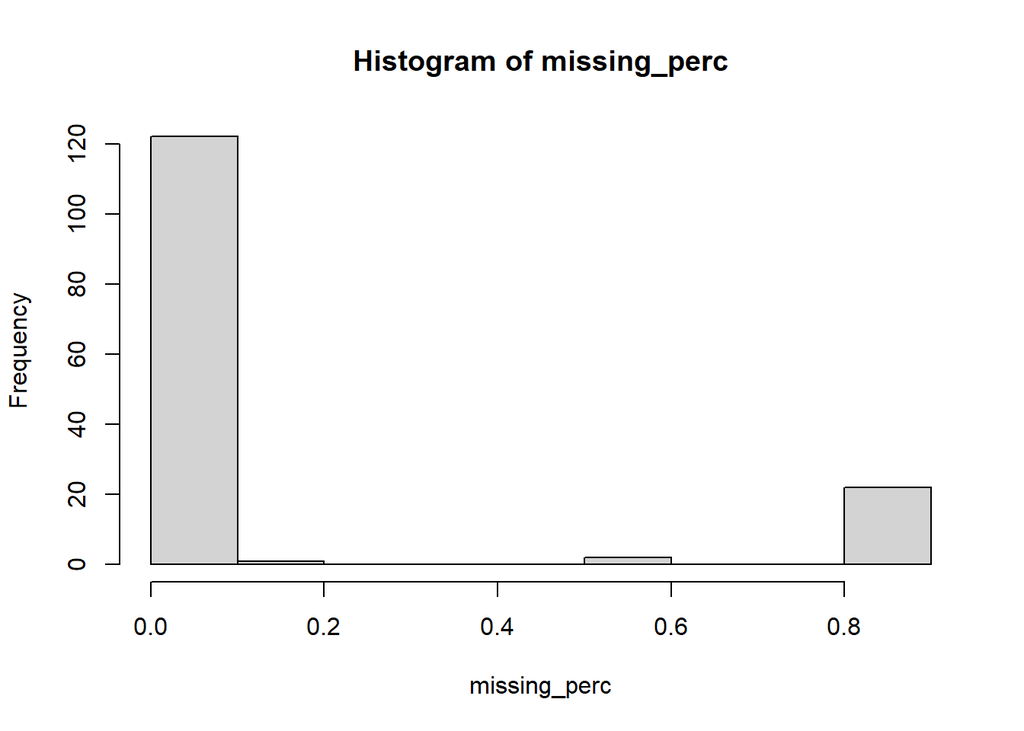

Ilosc zmiennych z brakami i histogram pokazujacy wielkosc tych brakow:

```r
#check missing by col
missing_perc = c()
length(colnames(df))
```

```
## [1] 125
```

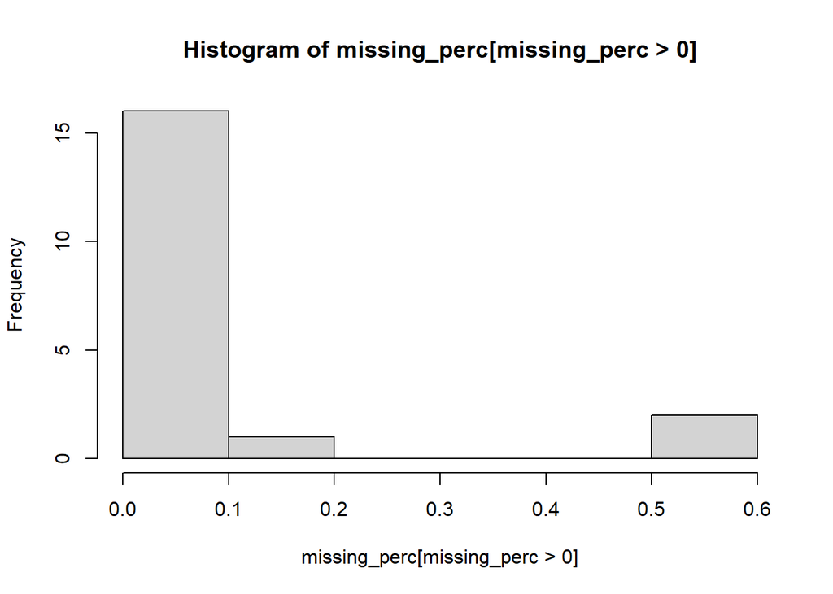

```r
for (i in 1:125){
  j = length(df[is.na(df[,i] == TRUE),i])/2115
  missing_perc = c(missing_perc,j)}
hist(missing_perc[missing_perc>0])
```

```r
df3 = df[,missing_perc >0]
```

Tablica korelacji / korelogram zmiennych z brakami danych z usunietymi wierszami zawierajacymi braki.

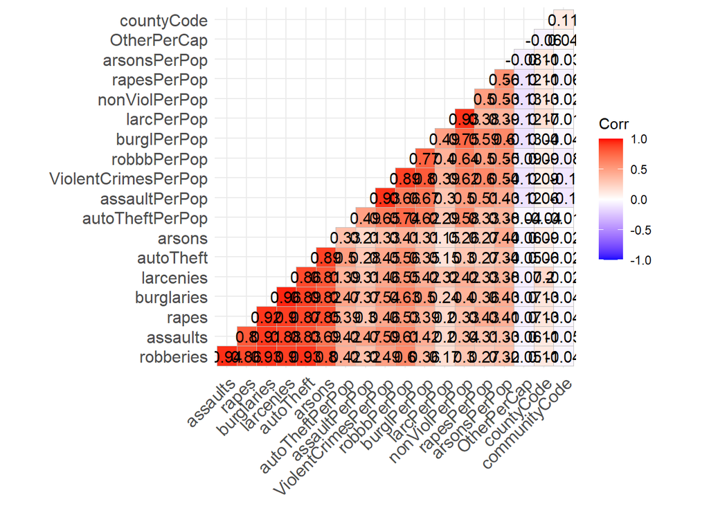

```r
varwithmissings = df[,missing_perc>0]
varwithmissings <- as.data.frame(lapply(varwithmissings,as.numeric))
cortable = cor(na.omit(varwithmissings))
library(ggcorrplot)
ggcorrplot::ggcorrplot(cortable, hc.order = TRUE, type = "lower",
           lab = TRUE)
```

Dendrogram braków danych.

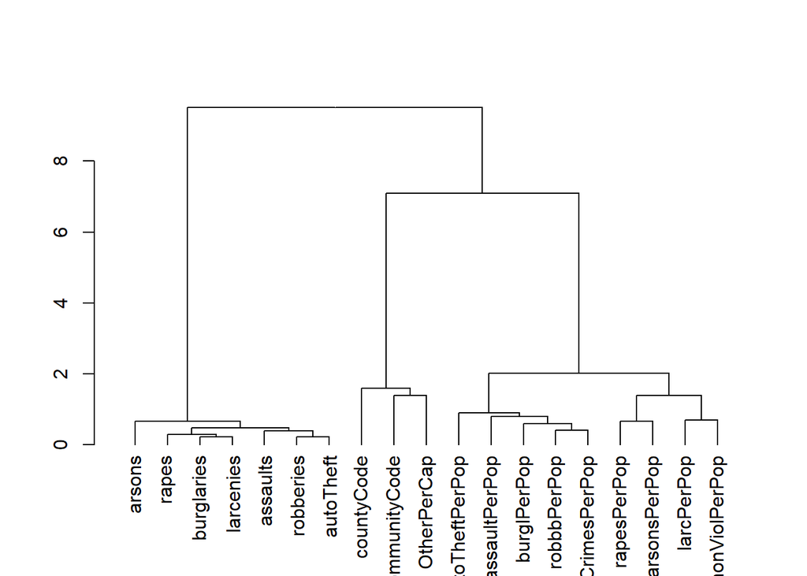

```r
dd <- dist(cortable, method = "euclidean")
hc <- hclust(dd, method = "ward.D")
hcd = as.dendrogram(hc)
plot(hcd, horiz = FALSE)
```

Wnioski:  
- Braki w rapesPerPop i w rapes są takie same bo **rapesPerPop=rapes/population**  
- ViolentCrimesPerPop sa **MNAR**(mostly not at random) sa skorelowane z brakami rapes i assaults(takze skladniki violentcrimes)  
- nonViolPerPop są skorelowane z arsons, burglaries i autoTheft - skladniki nonViolPerPop - **MNAR**  
- Braki w robberies, assaults, burglaries, larcenies, autoTheft - **MCAR**.

IMPUTACJA DANYCH:  
srednimi  
algorytm KNN metoda warda medianami

Ilosc brakow w zmiennych robberies, rapes, burglaries, assaults:

```r
meanimput = df
paste('ilosc brakow w robberies: ' ,length(meanimput$robberies[is.na(meanimput$robberies) == TRUE]) )
```

```
## [1] "ilosc brakow w robberies:  1"
```

```r
paste('ilosc brakow w rapes: ' ,length(meanimput$rapes[is.na(meanimput$rapes) == TRUE]))
```

```
## [1] "ilosc brakow w rapes:  208"
```

```r
paste('ilosc brakow w burglaries: ' ,length(meanimput$burglaries[is.na(meanimput$burglaries) == TRUE]))
```

```
## [1] "ilosc brakow w burglaries:  3"
```

```r
paste('ilosc brakow w assaults: ' ,length(meanimput$assaults[is.na(meanimput$assaults) == TRUE]))
```

```
## [1] "ilosc brakow w assaults:  13"
```

Imputacja i porownanie statystyk/ rozkladow zmiennych robberies, rapes, burglaries, assaults:  
czerwony - bez imputacji  
blue - imputacja knn  
green - imputacja srednimi  
orange - imputacja medianami

```r
library(VIM)
library(ggplot2)
#knn
knnvalues = kNN(df, variable= c("robberies","rapes","burglaries","assaults"),k=5)
#imputacja srednia
meanimput = df
meanimput$robberies[is.na(meanimput$robberies) == TRUE] = mean(as.numeric(df$robberies[is.na(df$robberies) ==FALSE ]))
meanimput$rapes[is.na(meanimput$rapes) == TRUE] = mean(as.numeric(df$rapes[is.na(df$rapes) ==FALSE ]))
meanimput$burglaries[is.na(meanimput$burglaries) == TRUE] = mean(as.numeric(df$burglaries[is.na(df$burglaries) ==FALSE ]))
meanimput$assaults[is.na(meanimput$assaults) == TRUE] = mean(as.numeric(df$assaults[is.na(df$assaults) ==FALSE ]))
#imputacja mediana
medianimput = df
medianimput$robberies[is.na(medianimput$robberies) == TRUE] = median(as.numeric(df$robberies[is.na(df$robberies) ==FALSE ]))
medianimput$rapes[is.na(medianimput$rapes) == TRUE] = median(as.numeric(df$rapes[is.na(df$rapes) ==FALSE ]))
medianimput$burglaries[is.na(medianimput$burglaries  ) == TRUE] = median(as.numeric(df$burglaries[is.na(df$burglaries) ==FALSE ]))
medianimput$assaults[is.na(medianimput$assaults) == TRUE] = median(as.numeric(df$assaults[is.na(df$assaults) ==FALSE ]))
#zmiana rozkladow i statystyk do zmiennych po imputacji
#sumstats
summary(df[,c("robberies","rapes","burglaries","assaults")])
```

```
##    robberies           rapes           burglaries         assaults
##  Min.   :    0.0   Min.   :   0.00   Min.   :    2.0   Min.   :    0.0
##  1st Qu.:    5.0   1st Qu.:   2.00   1st Qu.:   95.0   1st Qu.:   18.0
##  Median :   19.0   Median :   7.00   Median :  205.0   Median :   56.0
##  Mean   :  237.9   Mean   :  28.05   Mean   :  761.2   Mean   :  326.5
##  3rd Qu.:   70.0   3rd Qu.:  19.00   3rd Qu.:  508.0   3rd Qu.:  180.0
##  Max.   :86001.0   Max.   :2818.00   Max.   :99207.0   Max.   :62778.0
##  NA's   :1         NA's   :208       NA's   :3         NA's   :13
```

```r
summary(knnvalues[,c("robberies","rapes","burglaries","assaults")])
```

```
##    robberies           rapes           burglaries         assaults
##  Min.   :    0.0   Min.   :   0.00   Min.   :    2.0   Min.   :    0.0
##  1st Qu.:    5.0   1st Qu.:   2.00   1st Qu.:   95.0   1st Qu.:   18.0
##  Median :   19.0   Median :   7.00   Median :  205.0   Median :   57.0
##  Mean   :  239.2   Mean   :  27.24   Mean   :  760.6   Mean   :  327.5
##  3rd Qu.:   70.0   3rd Qu.:  18.00   3rd Qu.:  507.5   3rd Qu.:  181.0
##  Max.   :86001.0   Max.   :2818.00   Max.   :99207.0   Max.   :62778.0
```

```r
summary(meanimput[,c("robberies","rapes","burglaries","assaults")])
```

```
##    robberies           rapes           burglaries         assaults
##  Min.   :    0.0   Min.   :   0.00   Min.   :    2.0   Min.   :    0.0
##  1st Qu.:    5.0   1st Qu.:   3.00   1st Qu.:   95.0   1st Qu.:   18.5
##  Median :   19.0   Median :   8.00   Median :  205.0   Median :   57.0
##  Mean   :  237.9   Mean   :  28.05   Mean   :  761.2   Mean   :  326.5
##  3rd Qu.:   70.0   3rd Qu.:  28.00   3rd Qu.:  511.5   3rd Qu.:  183.0
##  Max.   :86001.0   Max.   :2818.00   Max.   :99207.0   Max.   :62778.0
```

```r
summary(medianimput[,c("robberies","rapes","burglaries","assaults")])
```

```
##    robberies           rapes           burglaries         assaults
##  Min.   :    0.0   Min.   :   0.00   Min.   :    2.0   Min.   :    0.0
##  1st Qu.:    5.0   1st Qu.:   3.00   1st Qu.:   95.0   1st Qu.:   18.5
##  Median :   19.0   Median :   7.00   Median :  205.0   Median :   56.0
##  Mean   :  237.8   Mean   :  26.07   Mean   :  760.5   Mean   :  324.9
##  3rd Qu.:   70.0   3rd Qu.:  17.00   3rd Qu.:  507.5   3rd Qu.:  178.5
##  Max.   :86001.0   Max.   :2818.00   Max.   :99207.0   Max.   :62778.0
```

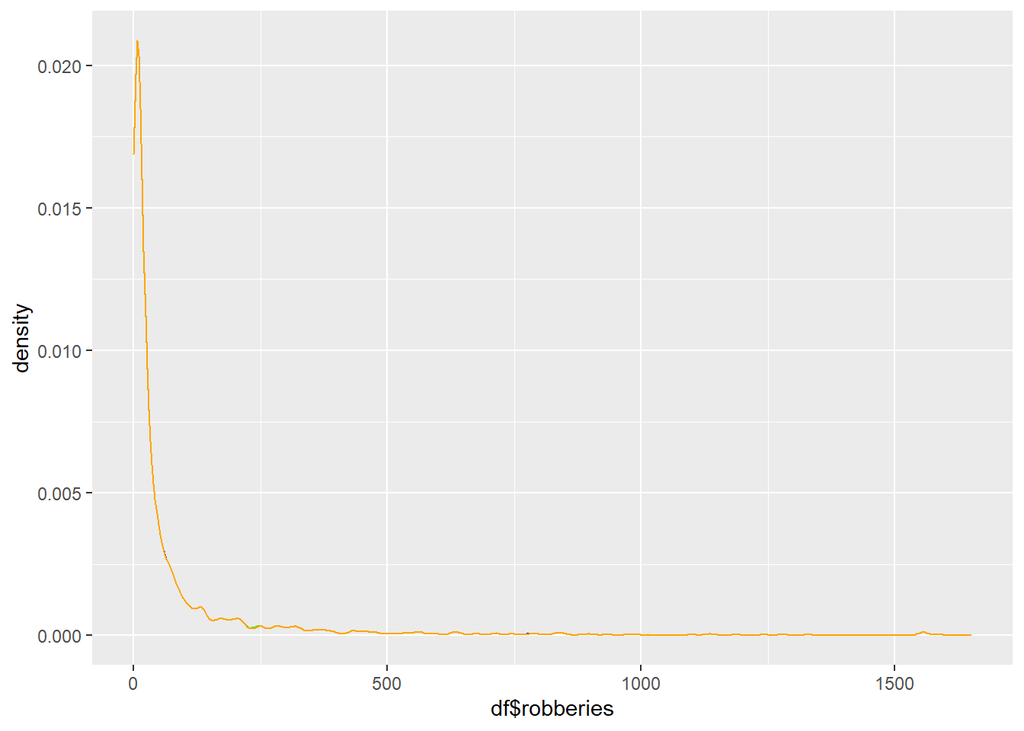

```r
#histplots , ostatni percentyl - 95% , wartosci odstajace uciete

ggplot() +
  geom_density(aes(x = df$robberies), colour = "red") +
  geom_density(aes(x = knnvalues$robberies), colour = "blue") +
  geom_density(aes(x = meanimput$robberies), colour = "green") +
  geom_density(aes(x = medianimput$robberies), colour = "orange")+
  xlim(as.vector(quantile(df$robberies[is.na(df$robberies) == FALSE], c(.00, .98))))
```

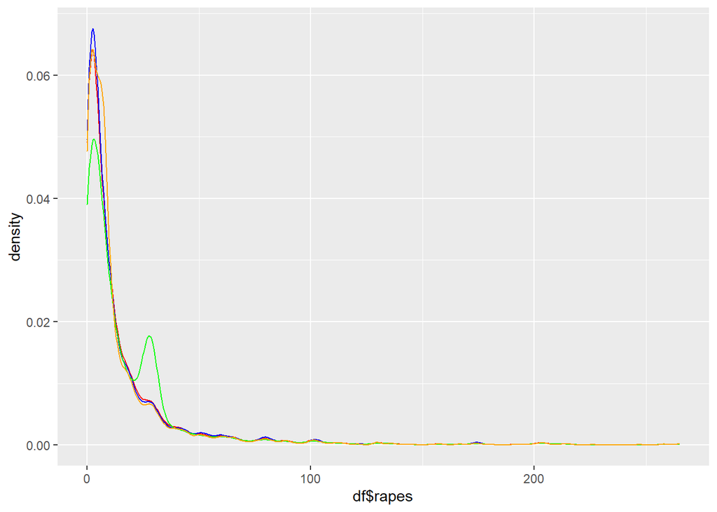

```r
ggplot() +
  geom_density(aes(x = df$rapes), colour = "red") +
  geom_density(aes(x = knnvalues$rapes), colour = "blue") +
  geom_density(aes(x = meanimput$rapes), colour = "green") +
  geom_density(aes(x = medianimput$rapes), colour = "orange")+
  xlim(as.vector(quantile(df$rapes[is.na(df$rapes) == FALSE], c(.00, .98))))
```

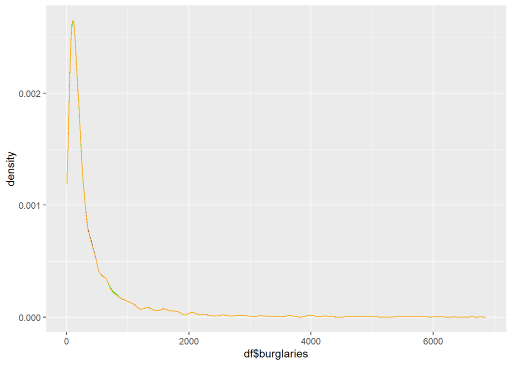

```r
ggplot() +
  geom_density(aes(x = df$burglaries), colour = "red") +
  geom_density(aes(x = knnvalues$burglaries), colour = "blue") +
  geom_density(aes(x = meanimput$burglaries), colour = "green") +
  geom_density(aes(x = medianimput$burglaries), colour = "orange")+
  xlim(as.vector(quantile(df$burglaries[is.na(df$burglaries) == FALSE], c(.00, .98))))
```

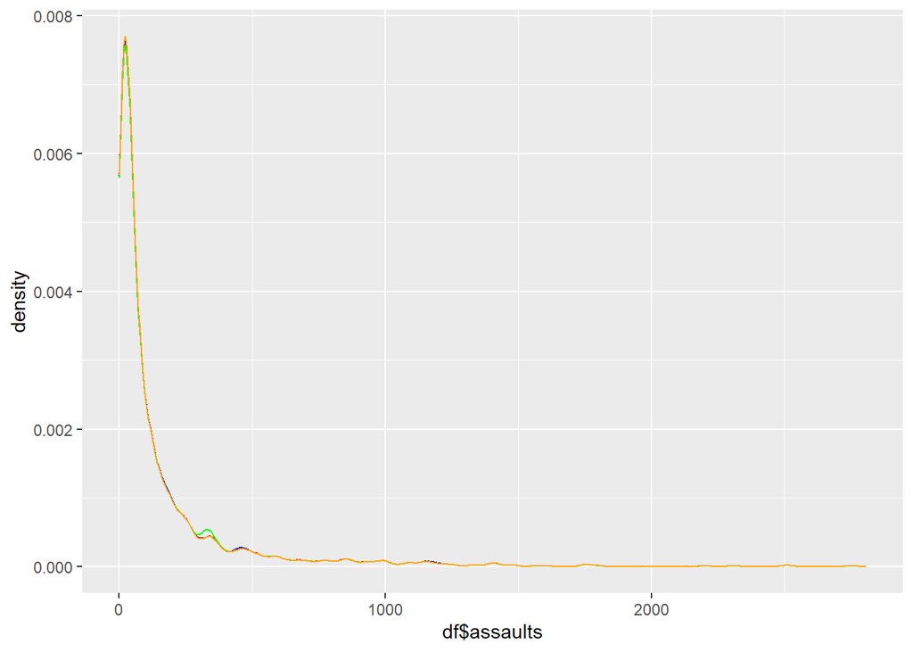

```r
ggplot() +
  geom_density(aes(x = df$assaults), colour = "red") +
  geom_density(aes(x = knnvalues$assaults), colour = "blue") +
  geom_density(aes(x = meanimput$assaults), colour = "green") +
  geom_density(aes(x = medianimput$assaults), colour = "orange")+
  xlim(as.vector(quantile(df$assaults[is.na(df$assaults) == FALSE], c(.00, .98))))
```

Ilosc brakow w zmiennych robbbPerPop, rapesPerPop, burglPerPop, assaultPerPop (zmienne gestosciowe):

```r
meanimput = df
paste('ilosc brakow w robberies: ' ,length(meanimput$robbbPerPop[is.na(meanimput$robbbPerPop) == TRUE]) )
```

```
## [1] "ilosc brakow w robberies:  1"
```

```r
paste('ilosc brakow w rapes: ' ,length(meanimput$rapesPerPop[is.na(meanimput$rapesPerPop) == TRUE]))
```

```
## [1] "ilosc brakow w rapes:  208"
```

```r
paste('ilosc brakow w burglaries: ' ,length(meanimput$burglPerPop[is.na(meanimput$burglPerPop) == TRUE]))
```

```
## [1] "ilosc brakow w burglaries:  3"
```

```r
paste('ilosc brakow w assaults: ' ,length(meanimput$assaultPerPop[is.na(meanimput$assaultPerPop) == TRUE]))
```

```
## [1] "ilosc brakow w assaults:  13"
```

Imputacja i pornownanie statystyk / rozkladow zmiennych gestosciowych:

```r
#poprawienie zmiennych na numeryczne
knnvalues = kNN(df, variable= c("robbbPerPop","rapesPerPop","burglPerPop","assaultPerPop"),k=5)
#imputacja srednia
meanimput$robbbPerPop[is.na(meanimput$robbbPerPop) == TRUE] = mean(as.numeric(df$robbbPerPop[is.na(df$robbbPerPop) ==FALSE ]))
meanimput$rapesPerPop[is.na(meanimput$rapesPerPop) == TRUE] = mean(as.numeric(df$rapesPerPop[is.na(df$rapesPerPop) ==FALSE ]))
meanimput$burglPerPop[is.na(meanimput$burglPerPop) == TRUE] = mean(as.numeric(df$burglPerPop[is.na(df$burglPerPop) ==FALSE ]))
meanimput$assaultPerPop[is.na(meanimput$assaultPerPop) == TRUE] = mean(as.numeric(df$assaultPerPop[is.na(df$assaultPerPop) ==FALSE ]))
#imputacja mediana
medianimput$robbbPerPop[is.na(medianimput$robbbPerPop) == TRUE] = median(as.numeric(df$robbbPerPop[is.na(df$robbbPerPop) ==FALSE ]))
medianimput$rapesPerPop[is.na(medianimput$rapesPerPop) == TRUE] = median(as.numeric(df$rapesPerPop[is.na(df$rapesPerPop) ==FALSE ]))
medianimput$burglPerPop[is.na(medianimput$burglPerPop) == TRUE] = median(as.numeric(df$burglPerPop[is.na(df$burglPerPop) ==FALSE ]))
medianimput$assaultPerPop[is.na(medianimput$assaultPerPop) == TRUE] = median(as.numeric(df$assaultPerPop[is.na(df$assaultPerPop) ==FALSE ]))
#sumstats
summary(df[,c("robbbPerPop","rapesPerPop","burglPerPop","assaultPerPop")])
```

```
##   robbbPerPop       rapesPerPop      burglPerPop       assaultPerPop
##  Min.   :   0.00   Min.   :  0.00   Min.   :   16.92   Min.   :   0.00
##  1st Qu.:  27.65   1st Qu.: 11.54   1st Qu.:  511.69   1st Qu.:  94.19
##  Median :  74.80   Median : 26.92   Median :  822.72   Median : 226.53
##  Mean   : 162.61   Mean   : 36.26   Mean   : 1033.43   Mean   : 378.00
##  3rd Qu.: 187.16   3rd Qu.: 51.47   3rd Qu.: 1350.23   3rd Qu.: 504.39
##  Max.   :2264.13   Max.   :401.35   Max.   :11881.02   Max.   :4932.50
##  NA's   :1         NA's   :208      NA's   :3          NA's   :13
```

```r
summary(knnvalues[,c("robbbPerPop","rapesPerPop","burglPerPop","assaultPerPop")])
```

```
##   robbbPerPop       rapesPerPop      burglPerPop       assaultPerPop
##  Min.   :   0.00   Min.   :  0.00   Min.   :   16.92   Min.   :   0.00
##  1st Qu.:  27.66   1st Qu.: 11.49   1st Qu.:  512.18   1st Qu.:  94.37
##  Median :  74.82   Median : 26.21   Median :  822.89   Median : 227.18
##  Mean   : 162.68   Mean   : 35.70   Mean   : 1033.79   Mean   : 378.00
##  3rd Qu.: 187.26   3rd Qu.: 50.74   3rd Qu.: 1351.10   3rd Qu.: 505.15
##  Max.   :2264.13   Max.   :401.35   Max.   :11881.02   Max.   :4932.50
```

```r
summary(meanimput[,c("robbbPerPop","rapesPerPop","burglPerPop","assaultPerPop")])
```

```
##   robbbPerPop       rapesPerPop      burglPerPop       assaultPerPop
##  Min.   :   0.00   Min.   :  0.00   Min.   :   16.92   Min.   :   0.00
##  1st Qu.:  27.66   1st Qu.: 13.39   1st Qu.:  512.18   1st Qu.:  94.75
##  Median :  74.82   Median : 30.86   Median :  823.71   Median : 228.68
##  Mean   : 162.61   Mean   : 36.26   Mean   : 1033.43   Mean   : 378.00
##  3rd Qu.: 187.15   3rd Qu.: 48.70   3rd Qu.: 1348.67   3rd Qu.: 502.62
##  Max.   :2264.13   Max.   :401.35   Max.   :11881.02   Max.   :4932.50
```

```r
summary(medianimput[,c("robbbPerPop","rapesPerPop","burglPerPop","assaultPerPop")])
```

```
##   robbbPerPop       rapesPerPop      burglPerPop       assaultPerPop
##  Min.   :   0.00   Min.   :  0.00   Min.   :   16.92   Min.   :   0.00
##  1st Qu.:  27.66   1st Qu.: 13.39   1st Qu.:  512.18   1st Qu.:  94.75
##  Median :  74.80   Median : 26.92   Median :  822.72   Median : 226.53
##  Mean   : 162.57   Mean   : 35.38   Mean   : 1033.14   Mean   : 377.12
##  3rd Qu.: 187.15   3rd Qu.: 48.70   3rd Qu.: 1348.67   3rd Qu.: 502.62
##  Max.   :2264.13   Max.   :401.35   Max.   :11881.02   Max.   :4932.50
```

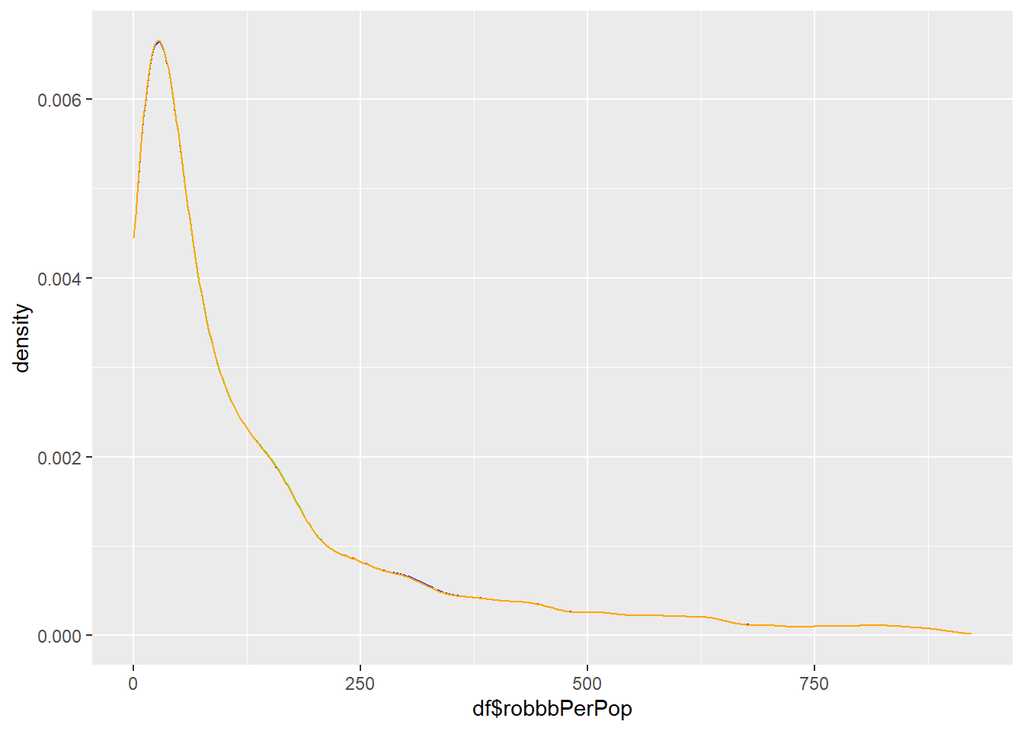

```r
#histplots , ostatni percentyl - 95% , wartosci odstajace uciete
#robbbPerPop
ggplot() +
  geom_density(aes(x = df$robbbPerPop), colour = "red") +
  geom_density(aes(x = knnvalues$robbbPerPop), colour = "blue") +
  geom_density(aes(x = meanimput$robbbPerPop), colour = "green") +
  geom_density(aes(x = medianimput$robbbPerPop), colour = "orange")+
  xlim(as.vector(quantile(df$robbbPerPop[is.na(df$robbbPerPop) == FALSE], c(.00, .98))))
```

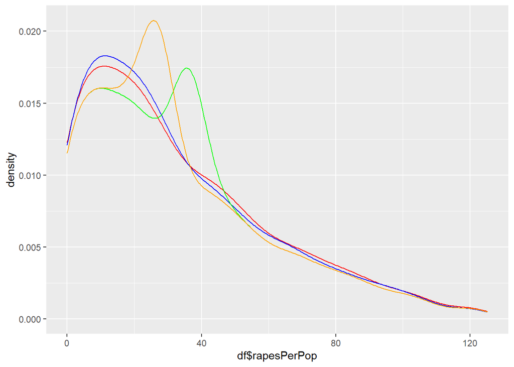

```r
ggplot() +
  geom_density(aes(x = df$rapesPerPop), colour = "red") +
  geom_density(aes(x = knnvalues$rapesPerPop), colour = "blue") +
  geom_density(aes(x = meanimput$rapesPerPop), colour = "green") +
  geom_density(aes(x = medianimput$rapesPerPop), colour = "orange")+
  xlim(as.vector(quantile(df$rapesPerPop[is.na(df$rapesPerPop) == FALSE], c(.00, .98))))
```

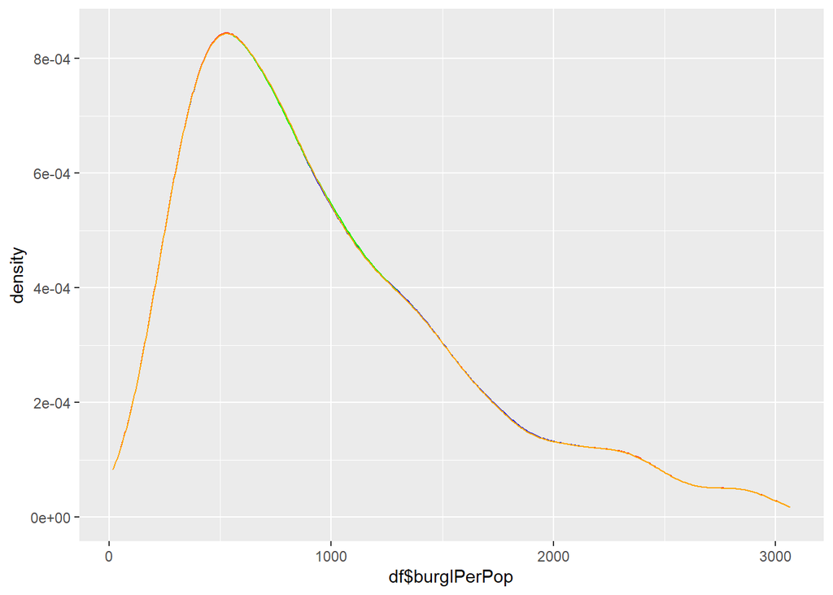

```r
ggplot() +
  geom_density(aes(x = df$burglPerPop), colour = "red") +
  geom_density(aes(x = knnvalues$burglPerPop), colour = "blue") +
  geom_density(aes(x = meanimput$burglPerPop), colour = "green") +
  geom_density(aes(x = medianimput$burglPerPop), colour = "orange")+
  xlim(as.vector(quantile(df$burglPerPop[is.na(df$burglPerPop) == FALSE], c(.00, .98))))
```

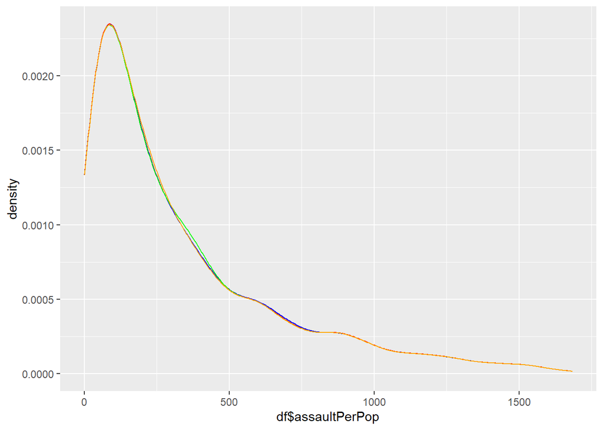

```r
ggplot() +
  geom_density(aes(x = df$assaultPerPop), colour = "red") +
  geom_density(aes(x = knnvalues$assaultPerPop), colour = "blue") +
  geom_density(aes(x = meanimput$assaultPerPop), colour = "green") +
  geom_density(aes(x = medianimput$assaultPerPop), colour = "orange")+
  xlim(as.vector(quantile(df$assaultPerPop[is.na(df$assaultPerPop) == FALSE], c(.00, .98))))
```